# **Discovering the Optimal Price**

Andrew Johns

## **Assignment Detail**

SafeBabies is a large company who is producing car seats for babies and toddlers. They sell their products all over the US and abroad. The management team has hired you as a Business Analytics consultant to help them maximizing their profit.

Your primary task is to determine:

1 - the optimal price for selling the car seats at those stores where the shelve location is good (i.e. the product is highly visible)?

2 - the optimal price for selling the car seats at those stores where the shelve location is bad (i.e. the product is barely visible)?

You have been told that the cost of producing each car seat is $55.0

1 - Plot the optimal price for selling the car seats at those stores where the shelve location is good and those where the shelve location is bad when varying the production costs from $40 to $85.

## **Variables for 400 Stores**

- **Sales** is unit sales (in thousands) at each location
- **Price** is the price that company charges for car seats at each site, and
- **ShelveLoc** is a factor with levels Bad, Good and Medium indicating the quality of the shelving location for the car seats at each store.

## **Loading Packages & Data**

```r
library(mlbench)
library(caret)
library(glmnet)
library(glmnetUtils)
library(plotmo)
library(dplyr)
library(ISLR)
SafeBabies <- Carseats %>% select("Sales", "Price", "ShelveLoc")
```

## **Modeling Shelve Locations**

```r
#Sort and Model Bad and Good Location
good.location <- SafeBabies %>% filter(ShelveLoc == "Good")
bad.location <- SafeBabies %>% filter(ShelveLoc == "Bad")

good.model <- lm(Sales ~ Price, data = good.location)
coefficients(good.model)
```

```
## (Intercept)       Price
## 17.96886360 -0.06578477
```

```r
bad.model <- lm(Sales ~ Price, data = bad.location)
coefficients(bad.model)
```

```
## (Intercept)       Price
## 11.83298389 -0.05522028
```

## **Calculating the Optimal Price and Total Profit**

**Price and Total Profit: Good Location**

```r
-(17.96886360-55*-0.06578477)/(2*(-0.06578477))
```

```
## [1] 164.0731
```

```r
-0.06578477*160.5731^2+(17.96886360-55*-0.06578477)*160.5731-55*17.96886360
```

```
## [1] 781.8321
```

**Price and Total Profit: Bad Location**

Optimal Price is ~$134.64 and Total Profit is ~$350,266.70 (350.2667*1,000, Sales in thousands)

```r
-(11.83298389-55*-0.05522028)/(2*(-0.05522028))
```

```
## [1] 134.6435
```

```r
-0.05522028*134.6435^2+(11.83298389-55*-0.05522028)*134.6435-55*11.83298389
```

```
## [1] 350.2667
```

## **Plotting the Optimal Price at Different Production Costs**

Below are loops to derive the optimal price with costs ranging from 40:85 increasing cost by 1 at each iteration. The graphs provide a positive linear relationship between optimal price and cost.

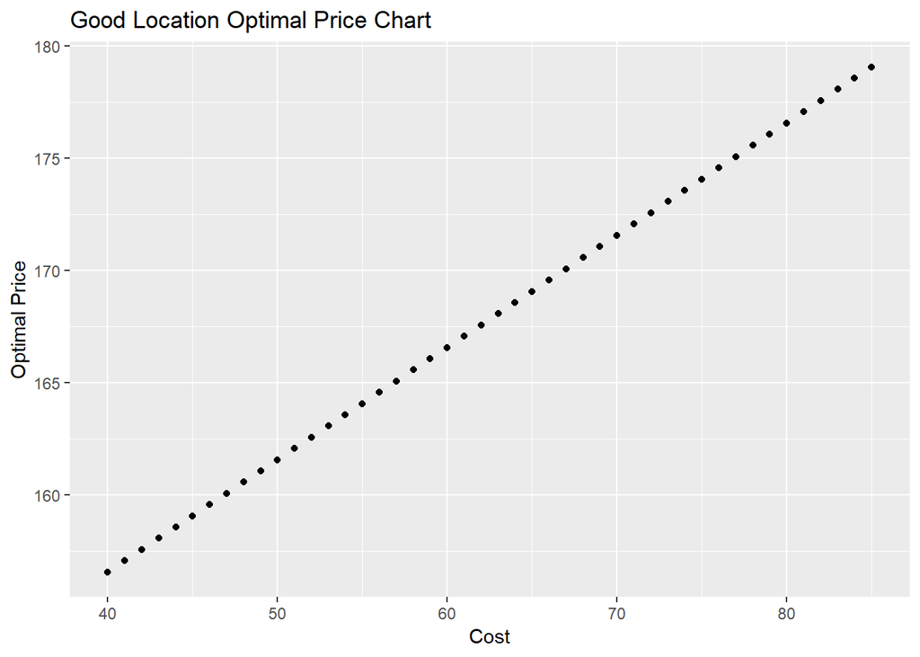

```r
cost.seq <- c(40:85)
good.opt.price <- matrix()
for (i in length(cost.seq)) {
  price <- -(17.96886360-cost.seq*-0.06578477)/(2*(-0.06578477))
  good.opt.price=price
}

good.var.cost <- data.frame(cost.seq, good.opt.price)

ggplot(good.var.cost, aes(x = cost.seq, y = good.opt.price)) +
  geom_point() +
  labs(x = "Cost", y = "Optimal Price", title = "Good Location Optimal Price Chart")
```

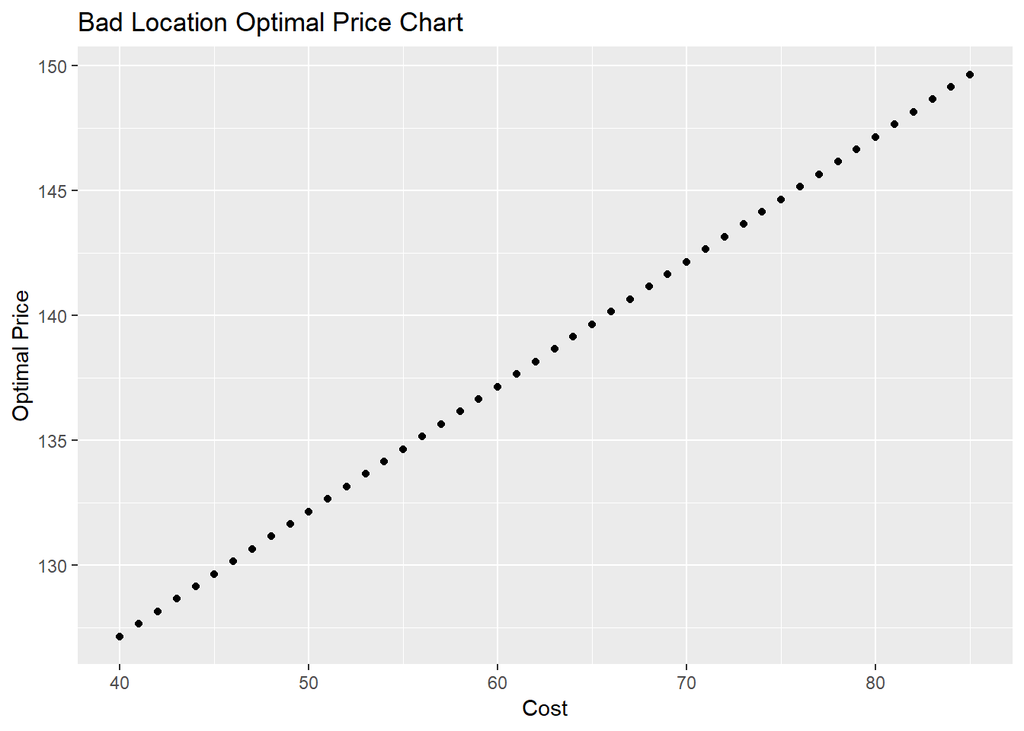

```r
cost.seq <- c(40:85)
good.opt.price <- matrix()
for (i in length(cost.seq)) {
  price <- -(11.83298389-cost.seq*-0.05522028)/(2*(-0.05522028))
  good.opt.price=price
}

good.var.cost <- data.frame(cost.seq, good.opt.price)

ggplot(good.var.cost, aes(x = cost.seq, y = good.opt.price)) +
  geom_point() +
  labs(x = "Cost", y = "Optimal Price", title = "Bad Location Optimal Price Chart")
```